# Preliminary analysis of NOAA storm event data

Steve Newbold

Friday, January 29, 2016

## Synopsis

I examined data from NOAA’s storm event database to determine which types of storm events 1) are most harmful to population health and 2) have the greatest economic consequences. To avoid data quality issues for early years in the database, I focused on events between 1990 and 2015.

## Data processing

This report includes the results of the analysis all R code used to conduct the analysis.

Download the data from the NOAA website:

```r
setInternet2(use=TRUE)
download.file(
"https://d396qusza40orc.cloudfront.net/repdata%2Fdata%2FStormData.csv.bz2",
"repdata-data-StormData.csv.bz2",method="auto")
```

Read data from the downloaded file into a data frame. (Note that ‘read.table’ can read zipped files directly.)

```r
data <- read.table("repdata-data-StormData.csv.bz2",header=TRUE,sep=",")
```

The type of storm event is recorded in the ‘EVTYPE’ column. Extract the unique set of event types and save these in a separate list to be used for looping later.

```r
event_types <- unique(data['EVTYPE'])
event_types <- event_types[order(event_types),]
```

Create a new column matrix with year for each record.

```r
I <- length(data[,1])
year <- matrix(0,I,1)
for(i in 1:I){
    temp1 <- data[i,"BGN_DATE"]
    temp2 <- as.character(temp1)
    temp3 <- unlist(strsplit(temp2,"/"))
    temp4 <- unlist(strsplit(temp3[3]," "))
    year[i] <- as.numeric(temp4[1])
}
```

Examine only those records for years 1990 and after.

```r
data <- data[year>=1990,]
```

Calculate the total fatalities, injuries, property damages, and crop damages for each event type since 1990.

```r
K         <-length(event_types)
event_fat <- matrix(0,K,1) # fatalities
event_inj <- matrix(0,K,1) # injuries
event_prp <- matrix(0,K,1) # property damage
event_crp <- matrix(0,K,1) # crop damage
for(k in 1:K){
    temp <- data[,'EVTYPE']==event_types[k]
    event_fat[k] <- sum(data[temp,"FATALITIES"])
    event_inj[k] <- sum(data[temp,"INJURIES"])
    event_prp[k] <- sum(data[temp,"PROPDMG"])
    event_crp[k] <- sum(data[temp,"CROPDMG"])
}
```

Sort the event types in decreasing size of each endpoint.

```r
#install.packages("xtable")
library(xtable)
order_fat <- order(event_fat,decreasing=TRUE)
temp1 <- event_types[order_fat]
temp2 <- event_fat[order_fat]
temp1[1:10]
```

```
##  [1] EXCESSIVE HEAT TORNADO        FLASH FLOOD    HEAT
##  [5] LIGHTNING      FLOOD          RIP CURRENT    TSTM WIND
##  [9] HIGH WIND      AVALANCHE
## 985 Levels:    HIGH SURF ADVISORY  COASTAL FLOOD ... WND
```

```r
temp2[1:10]
```

```
##  [1] 1903 1752  978  937  816  470  368  327  248  224
```

```r
order_inj <- order(event_inj,decreasing=TRUE)
temp3 <- event_types[order_inj]
temp4 <- event_inj[order_inj]
temp3[1:10]
```

```
##  [1] TORNADO           FLOOD             EXCESSIVE HEAT
##  [4] LIGHTNING         TSTM WIND         HEAT
##  [7] ICE STORM         FLASH FLOOD       THUNDERSTORM WIND
## [10] WINTER STORM
## 985 Levels:    HIGH SURF ADVISORY  COASTAL FLOOD ... WND
```

```r
temp4[1:10]
```

```
##  [1] 26674  6789  6525  5230  5022  2100  1975  1777  1488  1321
```

```r
order_prp <- order(event_prp,decreasing=TRUE)
temp5 <- event_types[order_prp]
temp6 <- event_prp[order_prp]
temp5[1:10]
```

```
##  [1] TORNADO            FLASH FLOOD        TSTM WIND
##  [4] FLOOD              THUNDERSTORM WIND  HAIL
##  [7] LIGHTNING          THUNDERSTORM WINDS HIGH WIND
## [10] WINTER STORM
## 985 Levels:    HIGH SURF ADVISORY  COASTAL FLOOD ... WND
```

```r
temp6[1:10]
```

```
##  [1] 1588733.0 1420124.6 1335965.6  899938.5  876844.2  688693.4  603351.8
##  [8]  446293.2  324731.6  132720.6
```

```r
order_crp <- order(event_crp,decreasing=TRUE)
temp7 <- event_types[order_crp]
temp8 <- event_crp[order_crp]
temp7[1:10]
```

```
##  [1] HAIL               FLASH FLOOD        FLOOD
##  [4] TSTM WIND          TORNADO            THUNDERSTORM WIND
##  [7] DROUGHT            THUNDERSTORM WINDS HIGH WIND
## [10] HEAVY RAIN
## 985 Levels:    HIGH SURF ADVISORY  COASTAL FLOOD ... WND
```

```r
temp8[1:10]
```

```
##  [1] 579596.28 179200.46 168037.88 109202.60 100018.52  66791.45  33898.62
##  [8]  18684.93  17283.21  11122.80
```

## Results

The table below shows ten event types that account for the greatest number of fatalities and injuries and the greatest amount of property damage and crop damage, respectively.

```r
df <- data.frame(temp1[1:10], temp2[1:10], temp3[1:10], temp4[1:10], temp5[1:10], temp6[1:10], temp7[1:10], temp8[1:10])
names(df) <- c('Event type','Fatalities','Event type','Injuries','Event type','Property damage','Event type','Crop damage')
table <- xtable(df)
print(table,type="html")
```

|  | Event type | Fatalities | Event type | Injuries | Event type | Property damage | Event type | Crop damage |
| --- | --- | --- | --- | --- | --- | --- | --- | --- |
| 1 | EXCESSIVE HEAT | 1903.00 | TORNADO | 26674.00 | TORNADO | 1588732.99 | HAIL | 579596.28 |
| 2 | TORNADO | 1752.00 | FLOOD | 6789.00 | FLASH FLOOD | 1420124.59 | FLASH FLOOD | 179200.46 |
| 3 | FLASH FLOOD | 978.00 | EXCESSIVE HEAT | 6525.00 | TSTM WIND | 1335965.61 | FLOOD | 168037.88 |
| 4 | HEAT | 937.00 | LIGHTNING | 5230.00 | FLOOD | 899938.48 | TSTM WIND | 109202.60 |
| 5 | LIGHTNING | 816.00 | TSTM WIND | 5022.00 | THUNDERSTORM WIND | 876844.17 | TORNADO | 100018.52 |
| 6 | FLOOD | 470.00 | HEAT | 2100.00 | HAIL | 688693.38 | THUNDERSTORM WIND | 66791.45 |
| 7 | RIP CURRENT | 368.00 | ICE STORM | 1975.00 | LIGHTNING | 603351.78 | DROUGHT | 33898.62 |
| 8 | TSTM WIND | 327.00 | FLASH FLOOD | 1777.00 | THUNDERSTORM WINDS | 446293.18 | THUNDERSTORM WINDS | 18684.93 |
| 9 | HIGH WIND | 248.00 | THUNDERSTORM WIND | 1488.00 | HIGH WIND | 324731.56 | HIGH WIND | 17283.21 |
| 10 | AVALANCHE | 224.00 | WINTER STORM | 1321.00 | WINTER STORM | 132720.59 | HEAVY RAIN | 11122.80 |

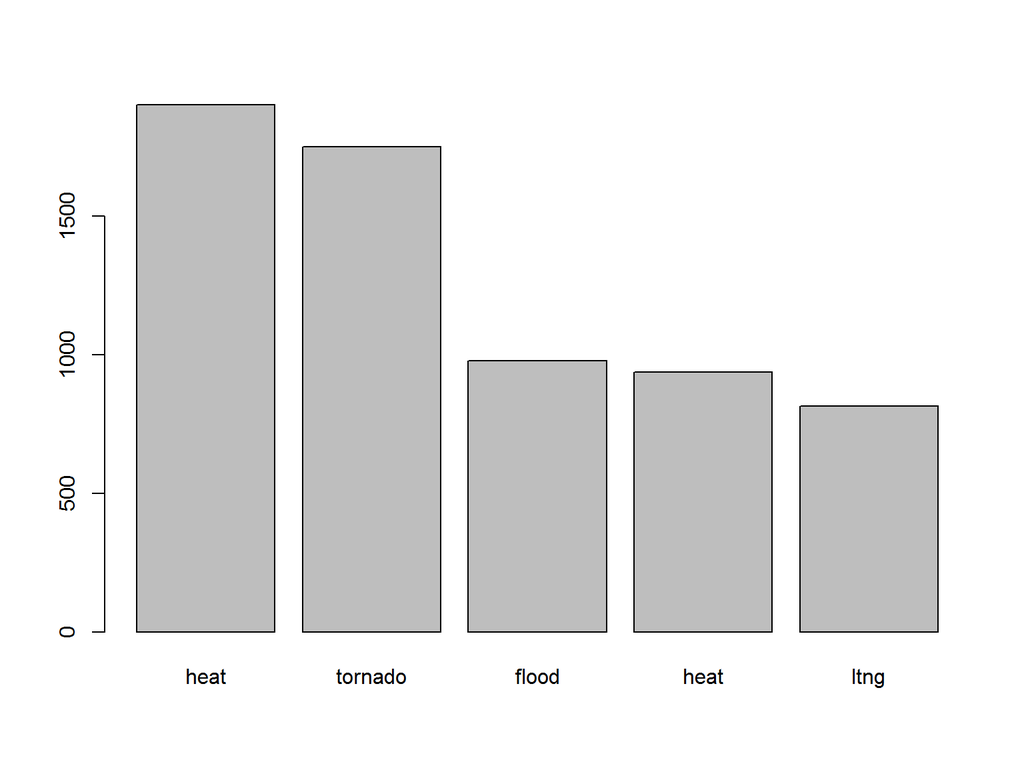

```r
#barplot(temp2[1:5],names.arg=temp1[1:5],horiz=FALSE)
barplot(temp2[1:5],names.arg=c('heat','tornado','flood','heat','ltng'),horiz=FALSE)
```

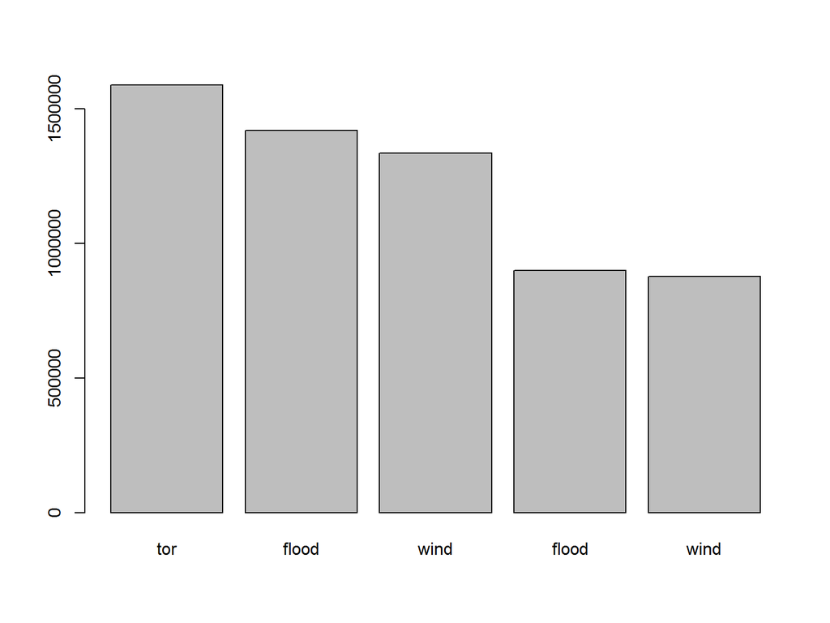

```r
barplot(temp6[1:5],names.arg=c('tor','flood','wind','flood','wind'),horiz=FALSE)
```

```r
trash <- 3
```